# GRADO DE DIFICULTAD DE LOS CURSOS GENERALES Y SU RELACIÓN CON LA CANTIDAD DE INGRESANTES (2022-I y 2022-II) DESAPROBADOS Y/O RETIRADOS EN UTEC

# **Análisis Descriptivo**

```
## [conflicted] Will prefer dplyr::filter over any other package.
## [conflicted] Will prefer dplyr::lag over any other package.
```

## **Descriptores Gráficos**

A partir de los datos que recolectamos mediante las encuestas y después de haberlos pasado por un proceso de limpieza se pudieron sacar los siguientes gráficos.

En este gráfico se puede observar el promedio que obtuvieron los estudiantes en los diferentes cursos de su primer ciclo, en el eje Y los valores solamente van desde 0 hasta un máximo de 10.4, esto debido a que en proyecto nos estamos centrando principalmente en aquellos estudiantes que desaprobaron los 3 cursos mas “importantes” durante el primer ciclo. Es por ello que en los siguiente gráficos donde se hace uso de la variable promedio, sus valores irán desde 0 hasta 10.4.

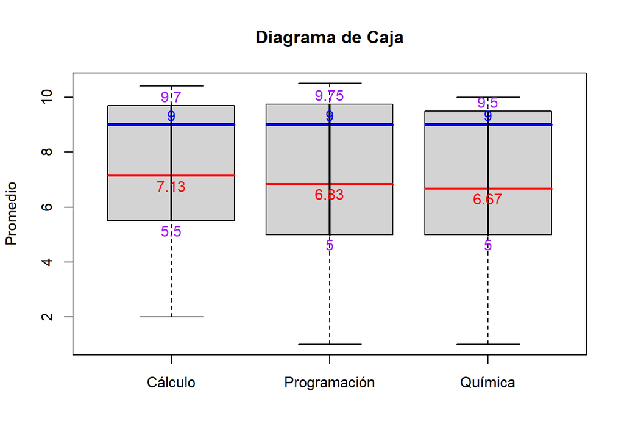

```r
# Filtrar los valores cero
DF_filtrado <- DF[DF$promedio_calculo != 0 & DF$promedio_progra != 0 & DF$promedio_quimica != 0, ]

# Calcular los cuartiles
q1_vals <- sapply(DF_filtrado[, c("promedio_calculo", "promedio_progra", "promedio_quimica")], quantile, probs = 0.25)
q3_vals <- sapply(DF_filtrado[, c("promedio_calculo", "promedio_progra", "promedio_quimica")], quantile, probs = 0.75)

# Crear el diagrama de caja
boxplot(DF_filtrado$promedio_calculo, DF_filtrado$promedio_progra, DF_filtrado$promedio_quimica,
        names = c("Cálculo", "Programación", "Química"),
        ylab = "Promedio", main = "Diagrama de Caja")

# Calcular la posición de las líneas
x <- c(1, 2, 3)
mean_vals <- sapply(DF_filtrado[, c("promedio_calculo", "promedio_progra", "promedio_quimica")], mean)
median_vals <- sapply(DF_filtrado[, c("promedio_calculo", "promedio_progra", "promedio_quimica")], median)

# Agregar las líneas para la media, mediana y rango intercuartil con un grosor mayor y tipo de línea "dashed"
segments(x - 0.4, mean_vals, x + 0.4, mean_vals, col = "red", lwd = 2, lty = "solid")
segments(x - 0.4, median_vals, x + 0.4, median_vals, col = "blue", lwd = 2, lty = "solid")
segments(x, q1_vals, x, q3_vals, col = "black", lwd = 2, lty = "solid")

# Agregar los valores de media, mediana y rango intercuartil
text(x, mean_vals, round(mean_vals, 2), pos = 1, offset = 0.3, col = "red") # 2 -> izquierda, 4 -> derecha, 1 -> arriba 3 -> abajo
text(x, median_vals, round(median_vals, 2), pos = 3, offset = 0.2, col = "blue")
text(x, q1_vals, round(q1_vals, 2), pos = 1, offset = 0.3, col = "purple")
text(x, q3_vals, round(q3_vals, 2), pos = 3, offset = 0.2, col = "purple")
```

## OBJETIVO 1

### Comprobar si la nivelación ayudó a afrontar de la mejor manera el primer ciclo.

**GRÁFICA 1: RELACIÓN ENTRE ASISTENCIA A LA NIVELACIÓN VS PROMEDIO EN CÁLCULO DE 1 VARIABLE**

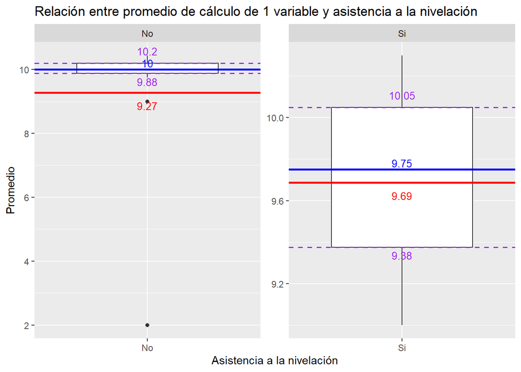

```r
library(ggplot2)
data <- data.frame(promedio = DF$promedio_calculo[DF$promedio_calculo != 0],
                   asistencia = factor(DF$Nivelacion[DF$promedio_calculo != 0]))

data <- na.omit(data)
#data <- data[!data %in% "no participo"]
mean_vals <- data %>%
  group_by(asistencia) %>%
  summarise(mean_val = mean(promedio),
            median_val = median(promedio),
            q1_val = quantile(promedio, 0.25),
            q3_val = quantile(promedio, 0.75))

ggplot(data, aes(x = asistencia, y = promedio)) +
  geom_boxplot() +
  geom_hline(data = mean_vals, aes(yintercept = mean_val), color = "red", linetype = "solid", size = 1) +
  geom_hline(data = mean_vals, aes(yintercept = median_val), color = "blue", linetype = "solid", size = 1) +
  geom_hline(data = mean_vals, aes(yintercept = q1_val), color = "purple", linetype = "dashed", size = 0.6) +
  geom_hline(data = mean_vals, aes(yintercept = q3_val), color = "purple", linetype = "dashed", size = 0.6) +
  geom_text(data = mean_vals, aes(x = asistencia, y = mean_val, label = round(mean_val, 2)), vjust = 2.1, color = "red", size = 3.5) +
  geom_text(data = mean_vals, aes(x = asistencia, y = median_val, label = round(median_val, 2)), vjust = -0.3, color = "blue", size = 3.5) +
  geom_text(data = mean_vals, aes(x = asistencia, y = q1_val, label = round(q1_val, 2)), vjust = 1.5, color = "purple", size = 3.5) +
  geom_text(data = mean_vals, aes(x = asistencia, y = q3_val, label = round(q3_val, 2)), vjust = -1, color = "purple", size = 3.5) +
  xlab("Asistencia a la nivelación") +
  ylab("Promedio") +
  ggtitle("Relación entre promedio de cálculo de 1 variable y asistencia a la nivelación") +
  facet_wrap(~asistencia, ncol = 2, scales = "free")  # Agregar facetas para separar los boxplots por asistencia
```

**Descriptor numérico**

**Estudiantes desaprobados que NO fueron a la nivelación (Bloxpot 1)**

Media -> 9.27 Mediana -> 10 Rango intercuartil -> 10.2 - 9.88 = 0.32

**Descriptor gráfico**

*¿Esto es suficiente para decir que en el curso de “Calculo de una variable” la nivelación no tuvo impacto en los estudiantes?*

No, ya que algo interesante sobre estos valores es que el primer diagrama de cajas se presentan dos datos atípicos (2 y 9), mientras que el segundo no presenta ningún dato atípico, esto realmente tiene sentido, ya que aquellos estudiantes quienes a pesar de haber desaprobado el curso de **Cálculo de 1 variable**, gracias a la nivelación sus conocimiento básicos fueron reforzados. Por ende, sus promedios de todo ese grupo no son tan bajos en comparación de los estudiantes que no fueron a la nivelación. La idea anterior se refuerza porque los estudiantes como consecuencia de no asistir a la nivelación, no pudieron reforzar sus conocimientos básicos; por lo cual las probabilidades de que ese grupo tuviera estudiantes con promedio muy bajos es mayor.

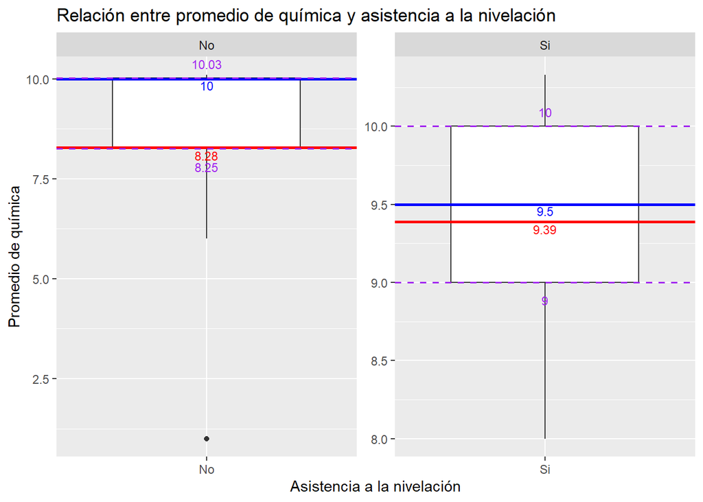

```r
data <- data.frame(promedio = DF$promedio_quimica[DF$promedio_quimica != 0],
                   asistencia = factor(DF$Nivelacion[DF$promedio_quimica != 0]))

data <- na.omit(data)
mean_vals <- data %>%
  group_by(asistencia) %>%
  summarise(mean_val = mean(promedio),
            median_val = median(promedio),
            q1_val = quantile(promedio, 0.25),
            q3_val = quantile(promedio, 0.75))

ggplot(data, aes(x = asistencia, y = promedio)) +
  geom_boxplot() +
  geom_hline(data = mean_vals, aes(yintercept = mean_val), color = "red", linetype = "solid", size = 1) +
  geom_hline(data = mean_vals, aes(yintercept = median_val), color = "blue", linetype = "solid", size = 1) +
  geom_hline(data = mean_vals, aes(yintercept = q1_val), color = "purple", linetype = "dashed", size = 0.6) +
  geom_hline(data = mean_vals, aes(yintercept = q3_val), color = "purple", linetype = "dashed", size = 0.6) +
  geom_text(data = mean_vals, aes(x = asistencia, y = mean_val, label = round(mean_val, 2)), vjust = 1.3, color = "red", size = 3) +
  geom_text(data = mean_vals, aes(x = asistencia, y = median_val, label = round(median_val, 2)), vjust = 1.2, color = "blue", size = 3) +
  geom_text(data = mean_vals, aes(x = asistencia, y = q1_val, label = round(q1_val, 2)), vjust = 2.4, color = "purple", size = 3) +
  geom_text(data = mean_vals, aes(x = asistencia, y = q3_val, label = round(q3_val, 2)), vjust = -1, color = "purple", size = 3) +
  xlab("Asistencia a la nivelación") +
  ylab("Promedio de química") +
  ggtitle("Relación entre promedio de química y asistencia a la nivelación") +
  facet_wrap(~asistencia, ncol = 2, scales = "free")  # Agregar facetas para separar los boxplots por asistencia
```

**Descriptores numéricos** **Estudiantes desaprobados que NO fueron a la nivelación (Bloxpot 1)**

**Estudiantes desaprobados que SI fueron a la nivelación (Bloxpot 2)**

Media -> 9.39 Mediana -> 9.5 Rango intercuartil -> 10 - 9 = 1

A diferencia del diagrama de cajas del curso de **Cálculo de 1 variable**, en este diagrama los estudiantes que no fueron a la nivelación no solamente tienen una mayor dispersión, sino que también tiene datos atípicos. Por lo tanto, se aprecia nuevamente que los estudiantes que Si fueron a la nivelación tienen un mejor promedio, ya que el 50% de los que pertenecen a este grupo tienen promedio entre 9 y 10, mientras que el resto tiene un promedio entre 8.25 y 10.03.

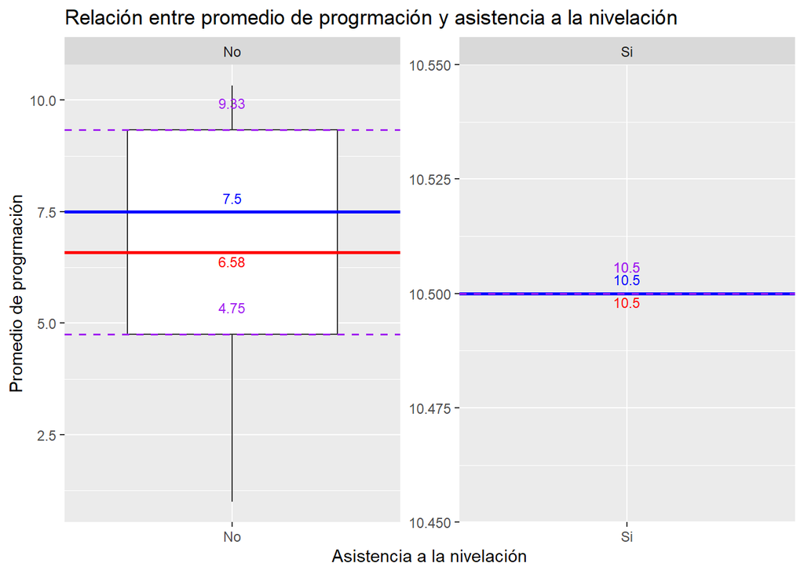

```r
data <- data.frame(promedio = DF$promedio_progra[DF$promedio_progra != 0],
                   asistencia = factor(DF$Nivelacion[DF$promedio_progra != 0]))

data <- na.omit(data)
mean_vals <- data %>%
  group_by(asistencia) %>%
  summarise(mean_val = mean(promedio),
            median_val = median(promedio),
            q1_val = quantile(promedio, 0.25),
            q3_val = quantile(promedio, 0.75),
            interquartile_range = q3_val - q1_val)  # Calcular el rango intercuartil

ggplot(data, aes(x = asistencia, y = promedio)) +
  geom_boxplot() +
  geom_hline(data = mean_vals, aes(yintercept = mean_val), color = "red", linetype = "solid", size = 1) +
  geom_hline(data = mean_vals, aes(yintercept = median_val), color = "blue", linetype = "solid", size = 1) +
  geom_hline(data = mean_vals, aes(yintercept = q1_val), color = "purple", linetype = "dashed", size = 0.6) +
  geom_hline(data = mean_vals, aes(yintercept = q3_val), color = "purple", linetype = "dashed", size = 0.6) +
  geom_text(data = mean_vals, aes(x = asistencia, y = mean_val, label = round(mean_val, 2)), vjust = 1.3, color = "red", size = 3) +
  geom_text(data = mean_vals, aes(x = asistencia, y = median_val, label = round(median_val, 2)), vjust = -0.8, color = "blue", size = 3) +
  geom_text(data = mean_vals, aes(x = asistencia, y = q1_val, label = round(q1_val, 2)), vjust = -2, color = "purple", size = 3) +
  geom_text(data = mean_vals, aes(x = asistencia, y = q3_val, label = round(q3_val, 2)), vjust = -2, color = "purple", size = 3) +

  xlab("Asistencia a la nivelación") +
  ylab("Promedio de progrmación") +
  ggtitle("Relación entre promedio de progrmación y asistencia a la nivelación") +
  facet_wrap(~asistencia, ncol = 2, scales = "free")  # Agregar facetas para separar los boxplots por asistencia
```

**interpretacion numerica**

**Estudiantes desaprobados que SI fueron a la nivelación (Bloxpot 2)**

Media -> 10.5 Mediana -> 10.5

**interpretación gráfica**

Así mismo, también concluimos que la nivelación es útil para poder sacar un mejor promedio en los cursos de “cálculo de una variable” y “química”, cumpliendo de tal manera con lo que su nombre lo indica *nivelar* a los estudiantes. Por lo que, en los 3 gráficos de los 3 cursos no vimos datos atípicos en el grupo que Sí asistió a la nivelación.

## OBJETIVO 2

### Identificar los cursos que tienen mayor o menor impacto en la tasa de abandono estudiantil.

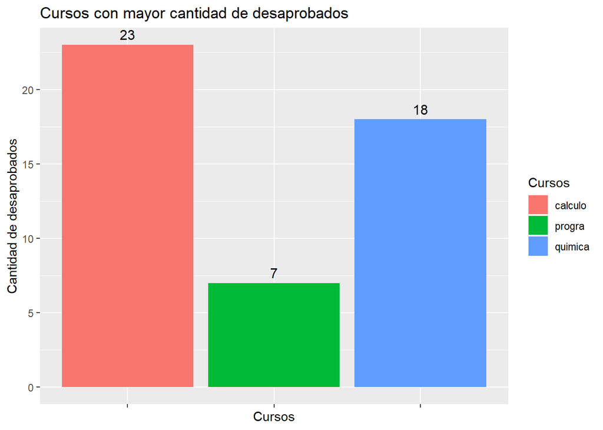

```r
# Filtrar las observaciones donde las variables "calculo", "quimica" y "progra" son TRUE
filtered_calculo <- DF[DF$calculo, ]
filtered_quimica <- DF[DF$quimica, ]
filtered_progra <- DF[DF$progra, ]


# Calcular la cantidad de desaprobados para cada curso
desaprobados_calculo <- sum(filtered_calculo$Veces_desaprobado)
desaprobados_quimica <- sum(filtered_quimica$Veces_desaprobado)
desaprobados_progra <- sum(filtered_progra$Veces_desaprobado)

# Crear un data frame con las variables de interés
data <- data.frame(Cursos = c("calculo", "quimica", "progra"),
                   Veces_desaprobado = c(desaprobados_calculo, desaprobados_quimica, desaprobados_progra))

# Generar el gráfico de barras
library(ggplot2)
ggplot(data, aes(x = Cursos, y = Veces_desaprobado, fill = Cursos)) +
  geom_bar(stat = "identity") +
  geom_text(aes(label = Veces_desaprobado), vjust = -0.5, color = "black", size = 4) +
  xlab("Cursos") +
  ylab("Cantidad de desaprobados") +
  ggtitle("Cursos con mayor cantidad de desaprobados") +
  scale_x_discrete(labels = NULL)
```

**Descriptores numéricos**

moda -> 23 – **Cálculo de 1 variable**

**Descriptor gráfico**

El gráfico de barras presente, muestra los 3 cursos con la mayor cantidad de desaprobados, los cursos se muestran en el eje x, mientras que la cantidad de desaprobados se representa en el eje y. Cabe resaltar que agrupamos la cantidad de estudiantes que desaprobaron, ya sea 2 o 3 cursos en un solo grupo de datos. Es decir, si un estudiante desaprobó tanto cálculo de 1 variable como química dicha observación fue repartida en dos columnas, en la de cálculo y la de química. No consideramos Lab. de Química porque no tiene mentoría, ni nivelación.

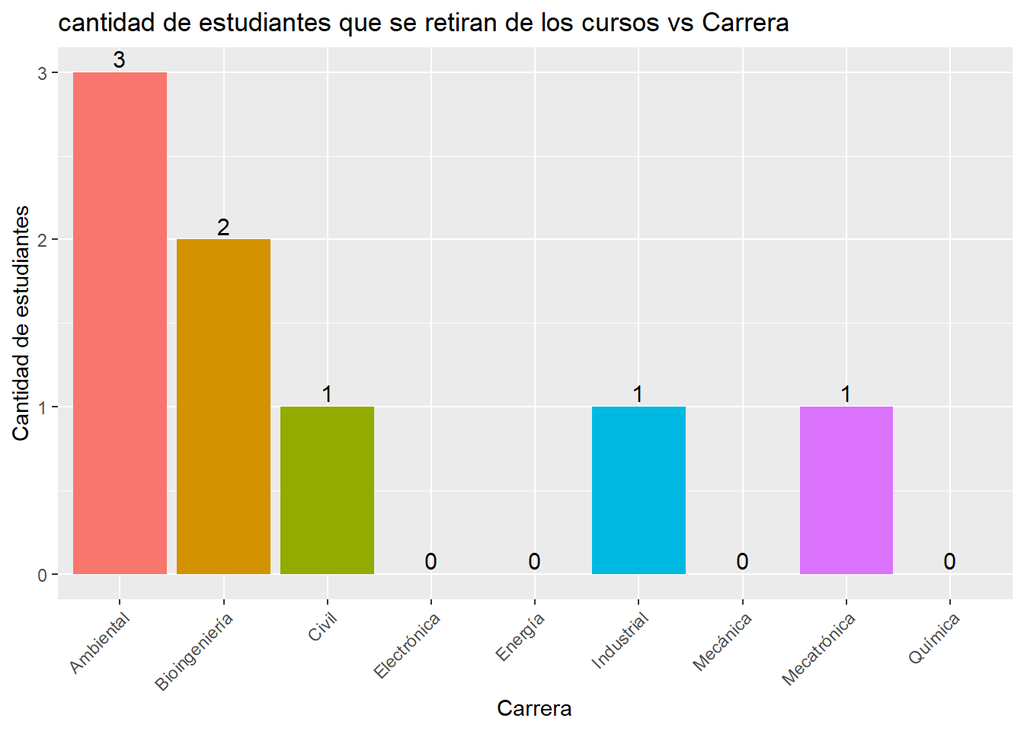

```r
filtered_data <- DF[!(DF$Veces_retirado == "NA" | DF$Carrera == "NA"), ]

data <- data.frame(repiticiones = filtered_data$Veces_retirado, carrera = filtered_data$Carrera)
sum_repeticiones <- aggregate(repiticiones ~ carrera, data, sum)


library(ggplot2)
ggplot(sum_repeticiones, aes(x = carrera, y = repiticiones, fill = carrera)) +
  geom_bar(stat = "identity") +
  geom_text(aes(label = repiticiones), vjust = -0.3, color = "black", size = 4) +
  xlab("Carrera") +
  ylab("Cantidad de estudiantes") +
  ggtitle("cantidad de estudiantes que se retiran de los cursos vs Carrera") +
  theme(axis.text.x = element_text(angle = 45, hjust = 1),
        legend.position = "none")
```

```r
data <- data.frame(repiticiones = filtered_data$Veces_retirado, carrera = filtered_data$Carrera)
sum_repeticiones <- aggregate(repiticiones ~ carrera, data, sum)
```

**Descriptores numéricos**

Moda -> 3 – Ingeniería ambiental

**Descriptor gráfico**

La gráfica muestra la cantidad de estudiantes retirados en las diferentes carreras. Se observa que Ingeniería Ambiental se tiene la mayor cantidad de retirados (3), seguida de Bioingeniería (2). Las que tienen un retirado son: Ingeniería Civil, Ingeniería Industrial y Ingeniería Mecatrónica. Finalmente, no tienen retirados: Ingeniería Electrónica, Ingeniería de Energía e Ingeniería Mecánica.

En base a esta información, podemos observar que las carrera de Ingeniería Ambiental y Bioingeniería son las carreras con las tasas más altas de abandono estudiantil; mientras que Ingeniería Civil, Ingeniería Industrial e Ingeniería Mecatrónica también presentan un número significativo de estudiantes retirados en los cursos de Cálculo de 1 variable, Programación I y Química. No consideramos Lab. de Química porque no tiene mentoría.

Esta información nos ayuda a responder a nuestro segundo objetivo, ya que podemos plantear futuras soluciones en campos específicos ante el problema del abandono estudiantil. Cabe recalcar que al inicio la cantidad 8 estudiantes retirados no parece ser un problema, pero estamos hablando de estudiantes que se **retiran** de los cursos y que no solamente lo desaprueben, conviertiendose en un problema mayor de lo que parece.

## OBEJTIVO 3

### Confirmar la necesidad de más mentores y asesorías en los cursos que se requieran.

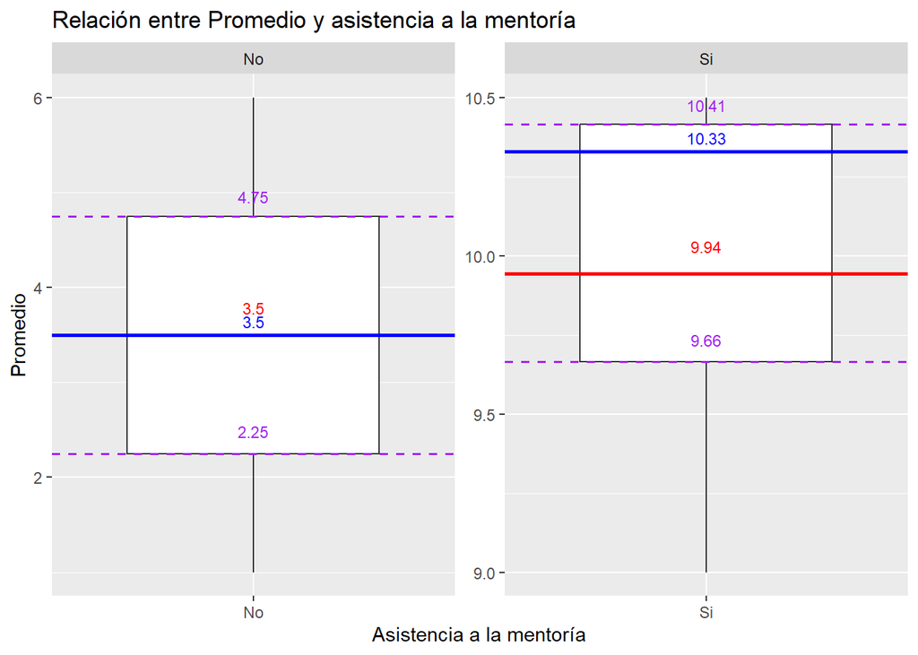

```r
data <- data.frame(promedio = DF$promedio_progra[DF$promedio_progra != 0],
                   asistencia = factor(DF$mentoria[DF$promedio_progra != 0]))

data <- na.omit(data)
#data <- data[!data %in% "no participo"]
mean_vals <- data %>%
  group_by(asistencia) %>%
  summarise(mean_val = mean(promedio),
            median_val = median(promedio),
            q1_val = quantile(promedio, 0.25),
            q3_val = quantile(promedio, 0.75),
            interquartile_range = q3_val - q1_val)  # Calcular el rango intercuartil

ggplot(data, aes(x = asistencia, y = promedio)) +
  geom_boxplot() +
  geom_hline(data = mean_vals, aes(yintercept = mean_val), color = "red", linetype = "solid", size = 1) +
  geom_hline(data = mean_vals, aes(yintercept = median_val), color = "blue", linetype = "solid", size = 1) +
  geom_hline(data = mean_vals, aes(yintercept = q1_val), color = "purple", linetype = "dashed", size = 0.6) +
  geom_hline(data = mean_vals, aes(yintercept = q3_val), color = "purple", linetype = "dashed", size = 0.6) +
  geom_text(data = mean_vals, aes(x = asistencia, y = mean_val, label = round(mean_val, 2)), vjust = -1.7, color = "red", size = 3) +
  geom_text(data = mean_vals, aes(x = asistencia, y = median_val, label = round(median_val, 2)), vjust = -0.6, color = "blue", size = 3) +
  geom_text(data = mean_vals, aes(x = asistencia, y = q1_val, label = round(q1_val, 2)), vjust = -1.3, color = "purple", size = 3) +
  geom_text(data = mean_vals, aes(x = asistencia, y = q3_val, label = round(q3_val, 2)), vjust = -1.1, color = "purple", size = 3) +

  xlab("Asistencia a la mentoría") +
  ylab("Promedio") +
  ggtitle("Relación entre Promedio y asistencia a la mentoría") +
  facet_wrap(~asistencia, ncol = 2, scales = "free")  # Agregar facetas para separar los boxplots por asistencia
```

**Descriptores numéricos**

**Estudiantes desaprobados que NO fueron a las mentorias (Bloxpot 1)**

media -> 3.5 mediana -> 3.5 rango intercuartil -> 4.75 - 2.25 = 2.5

**Descriptores gráficos**

En Bloxpot 1 podemos ver que la media y la mediana son iguales, lo cual indica que la distribución de datos está equilibrada en torno a un punto central. En este caso, no hay sesgo hacia los valores más altos o más bajos, lo que sugiere una distribución simétrica alrededor de la mediana.

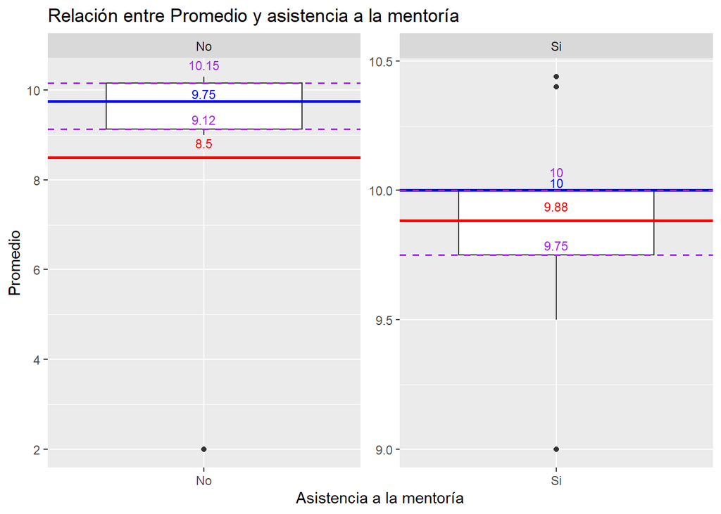

```r
data <- data.frame(promedio = DF$promedio_calculo[DF$promedio_calculo != 0],
                   asistencia = factor(DF$mentoria[DF$promedio_calculo != 0]))

data <- na.omit(data)
#data <- data[!data %in% "no participo"]
mean_vals <- data %>%
  group_by(asistencia) %>%
  summarise(mean_val = mean(promedio),
            median_val = median(promedio),
            q1_val = quantile(promedio, 0.25),
            q3_val = quantile(promedio, 0.75),
            interquartile_range = q3_val - q1_val)  # Calcular el rango intercuartil

ggplot(data, aes(x = asistencia, y = promedio)) +
  geom_boxplot() +
  geom_hline(data = mean_vals, aes(yintercept = mean_val), color = "red", linetype = "solid", size = 1) +
  geom_hline(data = mean_vals, aes(yintercept = median_val), color = "blue", linetype = "solid", size = 1) +
  geom_hline(data = mean_vals, aes(yintercept = q1_val), color = "purple", linetype = "dashed", size = 0.6) +
  geom_hline(data = mean_vals, aes(yintercept = q3_val), color = "purple", linetype = "dashed", size = 0.6) +
  geom_text(data = mean_vals, aes(x = asistencia, y = mean_val, label = round(mean_val, 2)), vjust = -1, color = "red", size = 3) +
  geom_text(data = mean_vals, aes(x = asistencia, y = median_val, label = round(median_val, 2)), vjust = -0.3, color = "blue", size = 3) +
  geom_text(data = mean_vals, aes(x = asistencia, y = q1_val, label = round(q1_val, 2)), vjust = -0.5, color = "purple", size = 3) +
  geom_text(data = mean_vals, aes(x = asistencia, y = q3_val, label = round(q3_val, 2)), vjust = -1.4, color = "purple", size = 3) +

  xlab("Asistencia a la mentoría") +
  ylab("Promedio") +
  ggtitle("Relación entre Promedio y asistencia a la mentoría") +
  facet_wrap(~asistencia, ncol = 2, scales = "free")  # Agregar facetas para separar los boxplots por asistencia
```

**Descriptores numéricos**

media -> 9.88 mediana -> 10 rango intercuartil -> 10 - 9.75 = 0.25

**Descriptores gráficos**

A diferencia del anterior diagrama de cajas del curso **programación I**, en este diagrama hay valores atípicos, por lo que tomamos a la mediana como medida de estudio y podemos observar que las medianas tienen valores casi iguales, siendo 9.75 del grupo que no fueron a la mentoría y 10 de los que sí fueron a la mentoría. Hay una diferencia leve entre estos dos valores pero no es suficiente como para asegurar que las mentorías realmente sean útiles a los estudiantes en el curso de **Cálculo de 1 variable**, por lo cual para este caso tomaremos al valor del rango intercuartil, este señala que en el Bloxpot 1 los promedios del 50% de los estudiantes están mucho más dispersos que en el Bloxpot 2. Asimismo, observamos que los datos atípicos del Bloxpot 2 no se encuetran demasiado lejos del diagrama de cajas, mientras que en el Bloxpot 1 ocurre lo contrario. Esto puede ser un indicador de que las mentorías ayudaron a resolver las dudas de los estudiantes, pero no fueron suficientes para que todos comprendan los temas en su totalidad.

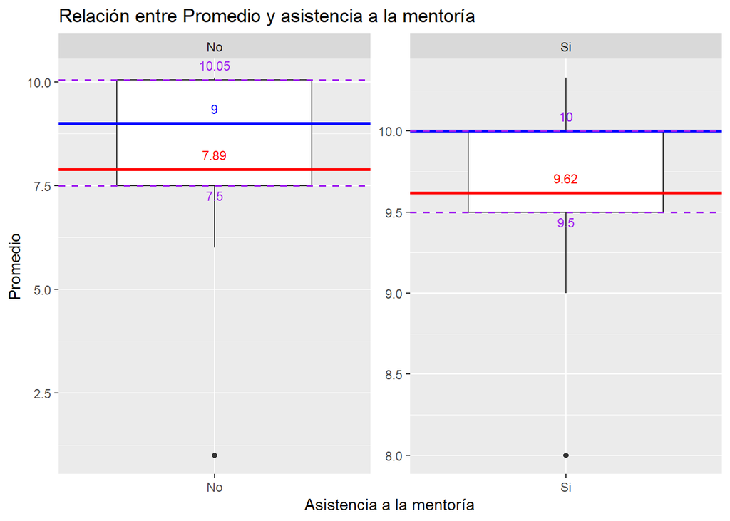

```r
library(tidyverse)

data <- data.frame(promedio = DF$promedio_quimica[DF$promedio_quimica != 0],
                   asistencia = factor(DF$mentoria[DF$promedio_quimica != 0]))

data <- na.omit(data)
#data <- data[!data %in% "no participo"]
mean_vals <- data %>%
  group_by(asistencia) %>%
  summarise(mean_val = mean(promedio),
            median_val = median(promedio),
            q1_val = quantile(promedio, 0.25),
            q3_val = quantile(promedio, 0.75),
            interquartile_range = q3_val - q1_val)  # Calcular el rango intercuartil

ggplot(data, aes(x = asistencia, y = promedio)) +
  geom_boxplot() +
  geom_hline(data = mean_vals, aes(yintercept = mean_val), color = "red", linetype = "solid", size = 1) +
  geom_hline(data = mean_vals, aes(yintercept = median_val), color = "blue", linetype = "solid", size = 1) +
  geom_hline(data = mean_vals, aes(yintercept = q1_val), color = "purple", linetype = "dashed", size = 0.6) +
  geom_hline(data = mean_vals, aes(yintercept = q3_val), color = "purple", linetype = "dashed", size = 0.6) +
  geom_text(data = mean_vals, aes(x = asistencia, y = mean_val, label = round(mean_val, 2)), vjust = -1, color = "red", size = 3) +
  geom_text(data = mean_vals, aes(x = asistencia, y = median_val, label = round(median_val, 2)), vjust = -1, color = "blue", size = 3) +
  geom_text(data = mean_vals, aes(x = asistencia, y = q1_val, label = round(q1_val, 2)), vjust = 1.5, color = "purple", size = 3) +
  geom_text(data = mean_vals, aes(x = asistencia, y = q3_val, label = round(q3_val, 2)), vjust = -1, color = "purple", size = 3) +

  xlab("Asistencia a la mentoría") +
  ylab("Promedio") +
  ggtitle("Relación entre Promedio y asistencia a la mentoría") +
  facet_wrap(~asistencia, ncol = 2, scales = "free")  # Agregar facetas para separar los boxplots por asistencia
```

**Descriptores numéricos**

media -> 7.89 mediana -> 9 rango intercuartil -> 10.05 - 7.5 = 2.55

media -> 9.62 mediana -> 10 rango intercuartil -> 10 - 9.5 = 0.5

**Descriptores gráficos**

En general podemos decir que las mentorias realmente ayudan a los estudiantes a mejorar sus calificaciones, principalmente en el curso de **Programación I**. Por lo que, si aumentamos el número de mentores ayudaría a aumentoar la cantidad de estudiantes que logren aprobar o por lo menos subir sus promedios. Sin embargo, cabe recalcar que si se llega a aumentar la cantidad de mentores, dichos mentores tienen que tener la facilidad de poder explicar muy bien a los estudiantes y poder resolver todas sus dudas, ya que muchas veces los mentores no cumplen con sus horas establecidas dado que ellos también son estudiantes y a veces no disponen de mucho tiempo, todo ello se puede observar en el siguiente diagrama.

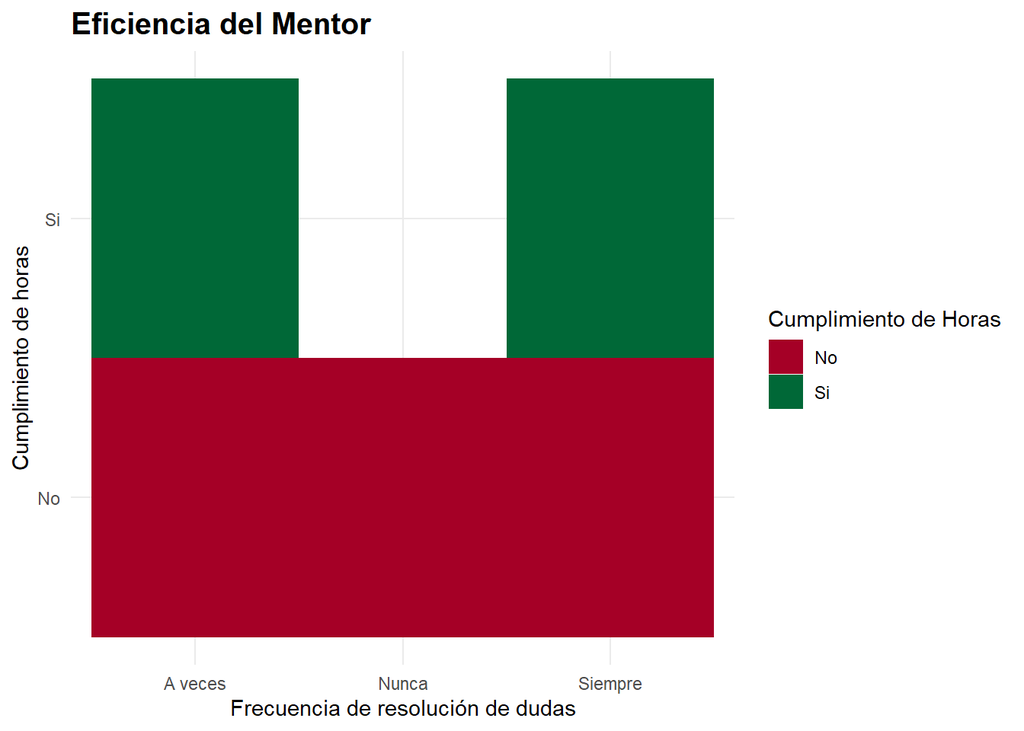

```r
DF_filtered <- DF %>%
  filter(!mentor_horas %in% "no participo", !mentor_dudas %in% "no participo")

ggplot(DF_filtered) +
  aes(x = mentor_horas, y = mentor_dudas, fill = mentor_horas) +
  geom_tile() +
  scale_fill_manual(
    values = c(No = "#A50026",
               Si = "#006837")
  ) +
  labs(
    x = "Cumplimiento de horas",
    y = "Frecuencia de resolución de dudas",
    title = "Eficiencia del Mentor",
    fill = "Cumplimiento de Horas"
  ) +
  coord_flip() +
  theme_minimal() +
  theme(plot.title = element_text(size = 15L, face = "bold"))
```

## OBJETIVO 4

### Comparar los promedios de horas dedicadas de estudio de los estudiantes que reprobaron algún curso.

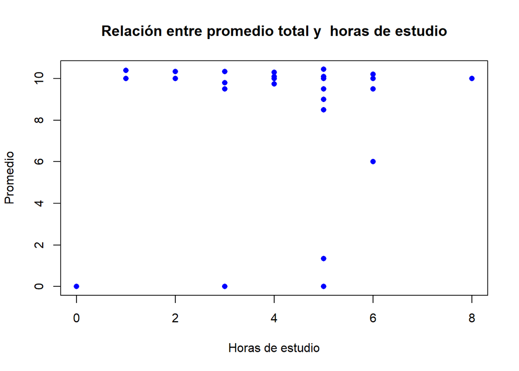

```r
# cursos jalados
filter_total_aprove <- DF[complete.cases(DF$promediototal, DF$horas_jalados), ] # horas de estudio que le dedican a los cursos que jalaron
# horas de estudio que ke dedican a los cursos que aprobaron

plot(filter_total_aprove$horas_jalados, filter_total_aprove$promediototal,
     xlab = "Horas de estudio", ylab = "Promedio",
     main = "Relación entre promedio total y  horas de estudio",
     col = "blue", pch = 16)
```

**interpretacion**

Este gráfico de dispersión muestra la relación entre el promedio total de los estudiantes desaprobados y sus horas de estudio dedicadas a los cursos que jalaron. El eje x representa las horas de estudio y el eje y representa el promedio total de los estudiantes desaprobados. Cada punto en el gráfico representa un estudiante y su posición en el gráfico indica su cantidad de horas de estudio y su promedio total. Podemos observar que la mayor cantidad de estudiantes desaprobados dedicaban de 3 a 6 horas de estudio. Esto posiblemente se debe a que al tratar de dedicar muchas horas de estudios a sus cursos no logran cumplir con las horas respectivas para cada uno.

En este gráfico de dispersión no se pueden sacar descriptores numéricos relevantes, dado que no hay un relación clara entre estas dos variables aparte de lo mencionado en el párrafo anterior. Cabe mencionar que si no existe mucha relación entre estas dos variable porque el promedio que se obtiene no siempre depende de las horas dedicadas a cada curso, ya que algunos “no estudian bien”; es decir, no aplican un método de estudio adecuado, por lo que a pesar de dedicarle muchas horas de estudio a un curso al final no tiene mucho impacto en sus promedios.

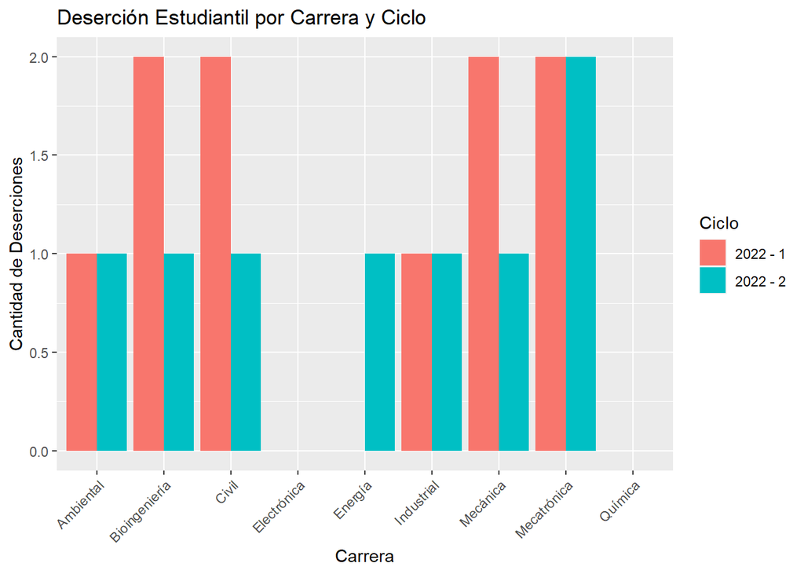

```r
# Crear un data frame con las variables relevantes
data <- data.frame(Carrera = DF$Carrera, Ciclo = DF$Ciclo, Desercion = DF$Veces_desaprobado)

# Filtrar los valores NA en la variable Desercion
data <- data[!is.na(data$Desercion), ]
#data <- data[!data %in% "no participo"]

# Generar el gráfico de barras agrupadas
ggplot(data, aes(x = Carrera, y = Desercion, fill = Ciclo)) +
  geom_bar(stat = "identity", position = "dodge") +
  xlab("Carrera") +
  ylab("Cantidad de Deserciones") +
  ggtitle("Deserción Estudiantil por Carrera y Ciclo") +
  theme(axis.text.x = element_text(angle = 45, hjust = 1))
```

**interpretacion** # tercer objetivo

El eje x representa las carreras, mientras que el eje y representa la cantidad de deserciones. Cada barra en el gráfico representa una combinación de carrera y ciclo, y la altura de la barra indica la cantidad de deserciones para esa combinación. Este gráfico de barras agrupadas permite visualizar y comparar la deserción estudiantil entre las diferentes carreras y ciclos. Puede ayudar a identificar las carreras o ciclos con tasas más altas de deserción, así como las posibles variaciones en la deserción a lo largo de los ciclos de cada carrera.

## OBJETIVO 5

# cuarto objetivo y quinto en uno solo

### Identificar el nivel de aprendizaje y dedicación de los alumnos en el curso.

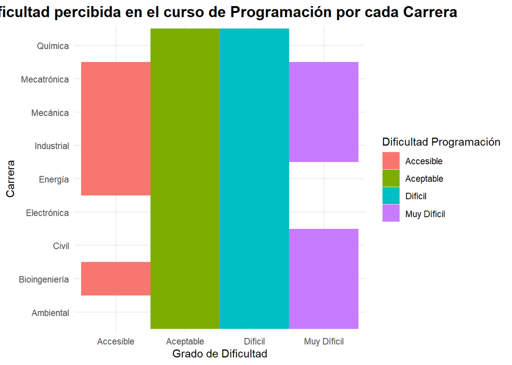

```r
# gráfico mosaico
ggplot(DF) +
 aes(x = Dificultad_progra, y = Carrera, fill = Dificultad_progra) +
 geom_tile() +
 scale_fill_hue(direction = 1) +
 labs(x = "Grado de Dificultad", y = "Carrera", title = "Dificultad percibida en el curso de Programación por cada Carrera",
 fill = "Dificultad Programación") +
 theme_minimal() +
 theme(plot.title = element_text(size = 15L,
 face = "bold", hjust = 0.5))
```

**Descriptor gráfico** El gráfico de teselas proporciona una representación visual de estas observaciones al mostrar los diferentes grados de dificultad percibida en el curso de Programación para cada carrera. Existen diferencias significativas en la forma en que los estudiantes de cada carrera perciben la dificultad del curso de Programación. Los estudiantes de algunas carreras, como Ingeniería Ambiental, Ingeniería Civil, Ingeniería Mecánica, Ingeniería Mecatrónica, Ingeniería Industrial y Bioingeniría perciben como “muy difícil” el curso de Programación. mientras que el resto de las carreras como mucho logra percibirlos como “difícil”.

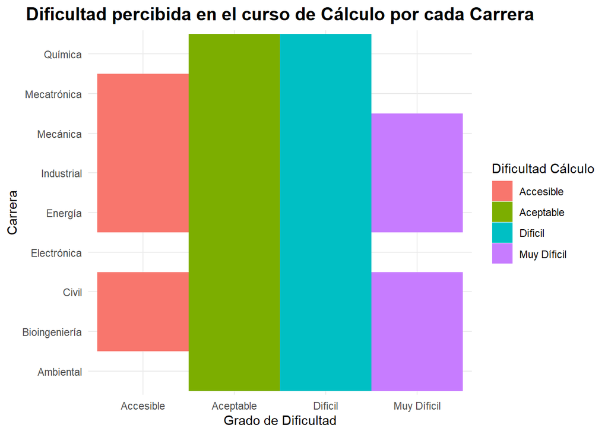

```r
ggplot(DF) +
 aes(x = Dificultad_calculo, y = Carrera, fill = Dificultad_calculo) +
 geom_tile() +
 scale_fill_hue(direction = 1) +
 labs(x = "Grado de Dificultad", y = "Carrera", title = "Dificultad percibida en el curso de Cálculo por cada Carrera",
 fill = "Dificultad Cálculo") +
 theme_minimal() +
 theme(plot.title = element_text(size = 15L,
 face = "bold", hjust = 0.5))
```

**interpretación**

A diferencia del gráfico de teselas enterior, en este gráfico el cual corresponde al curso de cálculo algunos estudiantes de la carrera de Ingeniería Ambiental, Ingeniería Civil y Ingeniería Industrial, perciben como “difícil” el curso de Cálculo. Por otro lado, carreras como Bioingeniería, Ingeniería Mecatrónica e Ingeniería de la Energía perciben como “aceptable” al curso de Cálculo.

Estos gráfico aparentemente no tienen mucha relación con la dedicación de los estudiantes en los diferentes cursos, sin embargo, estos gráficos nos ayudan a poder ver qué cursos les parece más dificil, y a partir de ello poder hacer un seguimiento en dicha carrera o en dicho curso, pues como vimos en el gráfico de dispersión, los estudiantes a pesar de que le dedicaban muchas horas de estudio a sus cursos estos desaprobaban, y una de las razones es que no comprenden muy bien los temas o no tienen material suficiente como para poder estudiar.

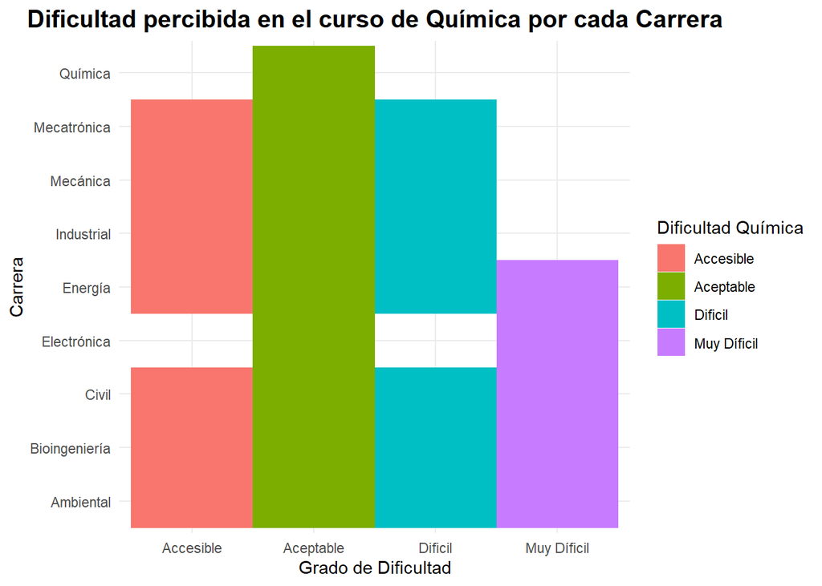

```r
ggplot(DF) +
 aes(x = Dificultad_quimica, y = Carrera, fill = Dificultad_quimica) +
 geom_tile() +
 scale_fill_hue(direction = 1) +
 labs(x = "Grado de Dificultad", y = "Carrera", title = "Dificultad percibida en el curso de Química por cada Carrera",
 fill = "Dificultad Química") +
 theme_minimal() +
 theme(plot.title = element_text(size = 15L,
 face = "bold", hjust = 0.5))
```

**Interpretación**

Con este último gráfico podemos recalcar que existen diferencias significativas en la forma en que los estudiantes de cada carrera perciben la dificultad del curso de Química, puesto que las 5 carreras de las 9 que hay, consideran a dicho curso como “muy difícil”.

Finalmente podemos decir que gracias a los diversos gráficos presentados pudimos observar que el promedio de un estudiante no solamente se dicta de acuerdo a las horas que este le puede dedicar a ciertos cursos, sino también depende de las oportunidades que pueda aprovechar, tales como las mentorias o la nivelación. Asimismo, tambien pudimos observar en qué carreras hay mayor tasa de abandono, esto es beneficioso porque al saber de antemano los cursos y carreras donde hay más abandono podemos plantear e implementar soluciones eficaces, como: el aumento de mentores, más material de estudio o brindando clases para dar técnicas a los estudiantes con mayores dificultades para un mayor entendimiento.